# Diseños metodológicos y su aplicación en el campo

Santiago Benitez-Vieyra

# Distribución Binomial.

### 1. Modelos para datos de presencia-ausencia.

# Proceso de Bernoulli

> serie de experimentos independientes donde la respuesta puede ser sólo de dos categorías.
- Es una respuesta binaria cualquier variable que pueda ser clasificada en sólo dos niveles: presencia/ausencia, morfo1/morfo2, … en general éxito/fracaso.
- La media de una distribución binaria es igual a la probabilidad de ocurrencia de éxitos.
- La varianza de una distribución binaria es igual a la probabilidad de ocurrencia de éxitos por la probabilidad de ocurrencia de fracasos.

# Proceso de Bernoulli

> serie de experimentos independientes donde la respuesta puede ser sólo de dos categorías.

$$P(y = 1) = p$$
$$P(y = 0) = 1-p$$
$$P(y) = p^y(1-p)^{1-y}$$

La variable respuesta se distribuye como Binomial
$$Y_{i} \sim B(N, p)$$
El enlace canónico es logit
$$\eta =log(\frac{\mu_{i}}{1-\mu{i}})$$
Por lo que el valor esperado es igual al logit inverso.
$$\mu_{i} = \frac{e^{\eta}}{1+e^{\eta}}$$

Colocando las variables predictoras en la parte sistemática…
$$\mu_{i} = \frac{e^{\beta_{0} + \beta_{1}X_{1i} + ... + \beta_{k}X_{ki}}}{1+e^{\beta_{0} + \beta_{1}X_{1i} + ... + \beta_{k}X_{ki}}}$$

# El enlace canónico espresa chances (odds).

$$logit(p(x)) = log\frac{p(x)}{1-p(x)}$$

Donde $p(x)$ es la probabilidad de éxito y $1-p(x)$ es la probabilidad de fracaso.

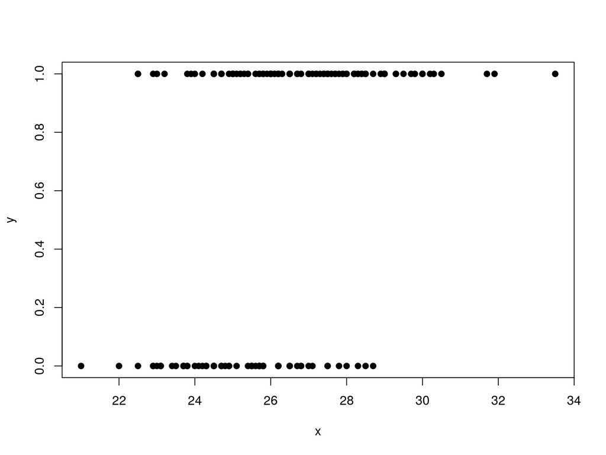

```r
dat <- read.table("horse.txt", header = TRUE)
fit <- glm(y ~ x, data = dat, family = binomial)
summary(fit)
```

```
##
## Call:
## glm(formula = y ~ x, family = binomial, data = dat)
##
## Deviance Residuals:
##     Min       1Q   Median       3Q      Max
## -2.0281  -1.0458   0.5480   0.9066   1.6942
##
## Coefficients:
##             Estimate Std. Error z value Pr(>|z|)
## (Intercept) -12.3508     2.6287  -4.698 2.62e-06 ***
## x             0.4972     0.1017   4.887 1.02e-06 ***
## ---
## Signif. codes:  0 '***' 0.001 '**' 0.01 '*' 0.05 '.' 0.1 ' ' 1
##
## (Dispersion parameter for binomial family taken to be 1)
##
##     Null deviance: 225.76  on 172  degrees of freedom
## Residual deviance: 194.45  on 171  degrees of freedom
## AIC: 198.45
##
## Number of Fisher Scoring iterations: 4
```

```r
dat <- read.table("horse.txt", header = TRUE)
fit <- glm(y ~ x, data = dat, family = binomial)
anova(fit, test = "Chisq")
```

```
## Analysis of Deviance Table
##
## Model: binomial, link: logit
##
## Response: y
##
## Terms added sequentially (first to last)
##
##
##      Df Deviance Resid. Df Resid. Dev  Pr(>Chi)
## NULL                   172     225.76
## x     1   31.306       171     194.45 2.204e-08 ***
## ---
## Signif. codes:  0 '***' 0.001 '**' 0.01 '*' 0.05 '.' 0.1 ' ' 1
```

```r
dat <- read.table("horse.txt", header = TRUE)
fit0 <- glm(y ~ 1, data = dat, family = binomial)
fit1 <- glm(y ~ x, data = dat, family = binomial)
anova(fit0, fit1, test = "Chisq")
```

```
## Analysis of Deviance Table
##
## Model 1: y ~ 1
## Model 2: y ~ x
##   Resid. Df Resid. Dev Df Deviance  Pr(>Chi)
## 1       172     225.76
## 2       171     194.45  1   31.306 2.204e-08 ***
## ---
## Signif. codes:  0 '***' 0.001 '**' 0.01 '*' 0.05 '.' 0.1 ' ' 1
```

# Interpretación de parámetros

```r
dat <- read.table("horse.txt", header = TRUE)
fit1 <- glm(y ~ x, data = dat, family = binomial)
exp(fit$coefficients)
```

```
##  (Intercept)            x
## 4.326214e-06 1.644162e+00
```

- La chance de tener éxito se incrementa 64.41% por cada unidad de aumento en la variable x.
- La probabilidad de tener éxito respecto a la probabilidad de no tenerlo se incrementa un 64.41%.
- El cociente de chances (odds ratio) es de 1.64 entre dos observaciones que difieran en una unidad.

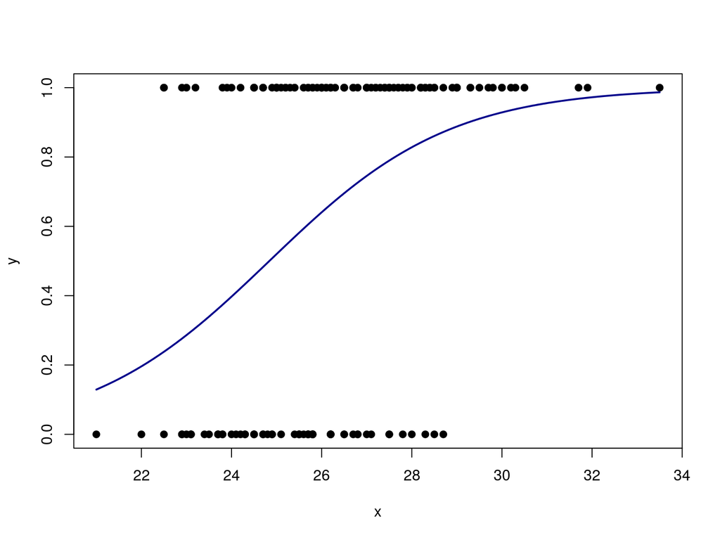

- En la regresión logística la probabilidad de éxito aumenta suavemente al principio, luego rápidamente y luego nuevamente en forma lenta al final.
- El logaritmo de la chance mantiene una relación lineal con la variable independiente.
- La ordenada al origen no es interpretable a menos que los datos hayan sido centrados, en cuyo caso equivale al logit de la media.

# La dosis letal 50%

- La dosis letal 50 toma su nombre de los ensayos de dosis-respuesta, en los cuales se aplica una dosis creciente de determinada droga y se examina una respuesta dicotómica (que habitualmente es muerte/supervivencia, de allí el nombre de letal).
- La LD50 indica el valor de la variable independiente a la cual obtenemos el mismo número de éxitos y de fracasos.

$$LD_{50} = -\beta_{0}/\beta_{1}$$

# Diagnósticos.

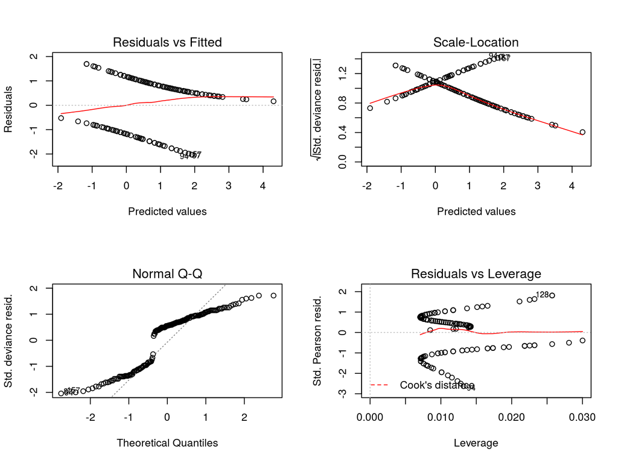

# Distribución Binomial.

### 2. Modelos para datos binomiales agrupados

# Datos binomiales agrupados

- Cada respuesta está constituida por más de un proceso de Bernoulli.
- Aplican a datos de PROPORCIONES, en general conocemos el número de éxitos y el número total de procesos de Bernoulli por sujeto (fracasos = total – éxito).
- La forma clásica de estudiarlas es aplicar la transformación arco-seno y realizar un modelo lineal, pero esto puede sesgar mucho nuestros resultados si el número de procesos de Bernoulli difiere entre los sujetos.

```r
dat <- read.table("gourlieana.txt", header = TRUE)
rta <- cbind(dat$pol.si, dat$pol.no)
fit <- glm(rta ~ espolon + flores, data = dat, family = binomial)
summary(fit)
```

```
##
## Call:
## glm(formula = rta ~ espolon + flores, family = binomial, data = dat)
##
## Deviance Residuals:
##     Min       1Q   Median       3Q      Max
## -3.1171  -1.1451   0.0584   0.8644   3.3657
##
## Coefficients:
##             Estimate Std. Error z value Pr(>|z|)
## (Intercept) -3.82541    0.84009  -4.554 5.27e-06 ***
## espolon      0.25991    0.06662   3.902 9.56e-05 ***
## flores       0.01628    0.01716   0.949    0.343
## ---
## Signif. codes:  0 '***' 0.001 '**' 0.01 '*' 0.05 '.' 0.1 ' ' 1
##
## (Dispersion parameter for binomial family taken to be 1)
##
##     Null deviance: 216.85  on 80  degrees of freedom
## Residual deviance: 201.26  on 78  degrees of freedom
## AIC: 409.67
##
## Number of Fisher Scoring iterations: 4
```

```r
dat <- read.table("gourlieana.txt", header = TRUE)
rta <- cbind(dat$pol.si, dat$pol.no)
fit <- glm(rta ~ espolon + flores, data = dat, family = binomial)
anova(fit, test = "Chisq")
```

```
## Analysis of Deviance Table
##
## Model: binomial, link: logit
##
## Response: rta
##
## Terms added sequentially (first to last)
##
##
##         Df Deviance Resid. Df Resid. Dev  Pr(>Chi)
## NULL                       80     216.84
## espolon  1  14.6886        79     202.16 0.0001268 ***
## flores   1   0.8991        78     201.26 0.3430157
## ---
## Signif. codes:  0 '***' 0.001 '**' 0.01 '*' 0.05 '.' 0.1 ' ' 1
```

### Bondad de ajuste

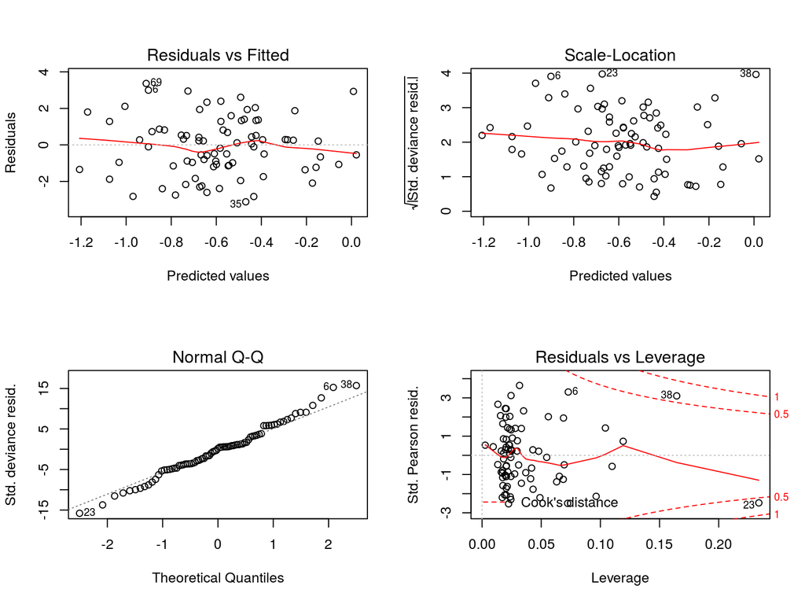

### Bondad de ajuste: sobredispersión.

```r
dat <- read.table("gourlieana.txt", header = TRUE)
rta <- cbind(dat$pol.si, dat$pol.no)
fit.q <- glm(rta ~ espolon + flores, data = dat, family = quasibinomial)
summary(fit.q)
```

```
##
## Call:
## glm(formula = rta ~ espolon + flores, family = quasibinomial,
##     data = dat)
##
## Deviance Residuals:
##     Min       1Q   Median       3Q      Max
## -3.1171  -1.1451   0.0584   0.8644   3.3657
##
## Coefficients:
##             Estimate Std. Error t value Pr(>|t|)
## (Intercept) -3.82541    1.28630  -2.974  0.00391 **
## espolon      0.25991    0.10200   2.548  0.01279 *
## flores       0.01628    0.02628   0.619  0.53741
## ---
## Signif. codes:  0 '***' 0.001 '**' 0.01 '*' 0.05 '.' 0.1 ' ' 1
##
## (Dispersion parameter for quasibinomial family taken to be 2.344379)
##
##     Null deviance: 216.85  on 80  degrees of freedom
## Residual deviance: 201.26  on 78  degrees of freedom
## AIC: NA
##
## Number of Fisher Scoring iterations: 4
```

### Modelos de cuasiverosimilitud.

```r
dat <- read.table("gourlieana.txt", header = TRUE)
rta <- cbind(dat$pol.si, dat$pol.no)
fit.q <- glm(rta ~ espolon + flores, data = dat, family = quasibinomial)
anova(fit.q, test = "F")
```

```
## Analysis of Deviance Table
##
## Model: quasibinomial, link: logit
##
## Response: rta
##
## Terms added sequentially (first to last)
##
##
##         Df Deviance Resid. Df Resid. Dev      F Pr(>F)
## NULL                       80     216.84
## espolon  1  14.6886        79     202.16 6.2655 0.0144 *
## flores   1   0.8991        78     201.26 0.3835 0.5375
## ---
## Signif. codes:  0 '***' 0.001 '**' 0.01 '*' 0.05 '.' 0.1 ' ' 1
```

### Adecuación del enlace

```r
dat <- read.table("gourlieana.txt", header = TRUE)
rta <- cbind(dat$pol.si, dat$pol.no)
fit <- glm(rta ~ espolon + flores, data = dat, family = binomial)
PL <- fit$linear.predictors^2
fit2 <- glm(rta ~ espolon + flores + PL, data = dat, family = binomial)
summary(fit2)
```

```
##
## Call:
## glm(formula = rta ~ espolon + flores + PL, family = binomial,
##     data = dat)
##
## Deviance Residuals:
##     Min       1Q   Median       3Q      Max
## -3.0619  -1.1211   0.1236   0.8965   3.3048
##
## Coefficients:
##             Estimate Std. Error z value Pr(>|z|)
## (Intercept) -6.29040    2.81956  -2.231   0.0257 *
## espolon      0.43586    0.20335   2.143   0.0321 *
## flores       0.02915    0.02222   1.312   0.1895
## PL           0.62963    0.68520   0.919   0.3581
## ---
## Signif. codes:  0 '***' 0.001 '**' 0.01 '*' 0.05 '.' 0.1 ' ' 1
##
## (Dispersion parameter for binomial family taken to be 1)
##
##     Null deviance: 216.85  on 80  degrees of freedom
## Residual deviance: 200.42  on 77  degrees of freedom
## AIC: 410.83
##
## Number of Fisher Scoring iterations: 4
```

# Interpretación de parámetros

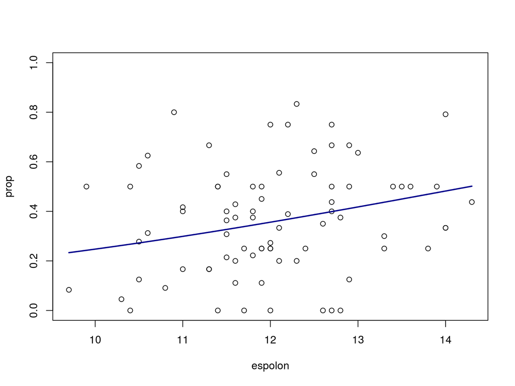

# Interpretación de parámetros

```r
dat <- read.table("gourlieana.txt", header = TRUE)
rta <- cbind(dat$pol.si, dat$pol.no)
fit <- glm(rta ~ espolon + flores, data = dat, family = quasibinomial)
fit$coefficients
exp(fit$coefficients)
exp(confint(fit))
```

[output not shown]